# R – Erste Schritte

Dr. Katja Nieberle

2026-03-15

## Was ist R?

R ist eine freie Programmiersprache und Softwareumgebung für statistische Berechnungen und Grafiken.  
Die aktuelle stabile Version ist R 4.5.2 (Stand Januar 2026).

R entstand 1993 an der University of Auckland (Neuseeland) als Open-Source-Weiterentwicklung der Sprache S (Bell Labs, ab 1976).  
Ross Ihaka und Robert Gentleman initiierten das Projekt; seit 1995 ist R öffentlich verfügbar.  
R steht unter der GPL-Lizenz (General Public License) und erlaubt damit die freie Nutzung, Modifikation und Verteilung von Code und Paketen.

R Studio bietet eine komfortable Entwicklungsumgebung für R.

Neben der Desktop-Version (RStudio Desktop, kostenlos, Version 2025.09.*) gibt es **Posit Cloud** (ehemals RStudio Cloud), eine browserbasierte IDE unter https://posit.cloud.  
Beachte dabei:

- Kostenlose Limits (z.B. Anzahl Projekte, Nutzungsstunden pro Monat)
- Datenschutz (Daten liegen in der Cloud)
- Notwendige stabile Internetverbindung

Posit Cloud eignet sich gut für Übungen ohne lokale Installation und für kollaboratives Arbeiten.

## CRAN

**CRAN** (Comprehensive R Archive Network) ist ein Netzwerk von Spiegelservern mit:

- R-Installationsdateien
- Dokumentation
- Tausenden von R-Paketen (über 20.000)

Pakete erweitern R um zusätzliche Funktionen, Datensätze und Grafiken (z.B. `ggplot2` für Visualisierung) und sind in der Regel ebenfalls Open Source.

## POSIT CLOUD

Öffne https://posit.cloud/ und registriere dich für eine kostenlose Version

[figure not shown]

[figure not shown]

[figure not shown]

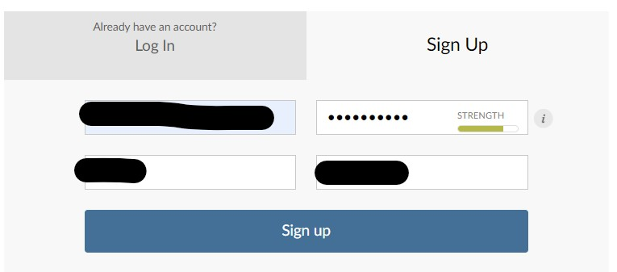

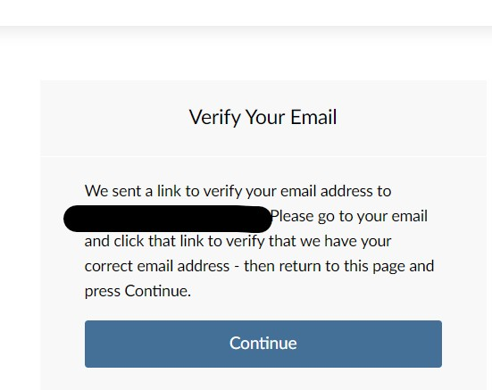

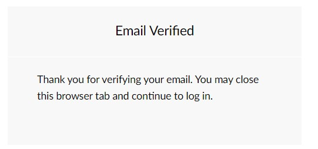

[figure not shown]

[figure not shown]

[figure not shown]

[figure not shown]

[figure not shown]

[figure not shown]

[4 more figures not shown]

## RStudio-Oberfläche

RStudio integriert R in eine benutzerfreundliche IDE (Integrated Development Environment) mit vier Hauptbereichen:

- **Source-Pane**: Skripte bearbeiten (`.R`, `.Rmd`) und ausführen (z.B. Strg + Enter).
- **Console-Pane**: Befehle direkt eingeben und Ergebnisse sofort sehen.
- **Environment/History-Pane**: Aktuelle Objekte und Befehlsverlauf.
- **Files/Plots/Packages/Help-Pane**: Dateien, Grafiken, Pakete und Hilfe.

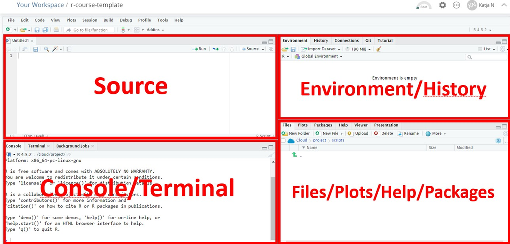

RStudio Oberfläche mit Beschriftungen

**Wichtig:** Speichere dein Skript regelmäßig mit **Strg + S**.

## Gängige Dateiformate für Daten

R kann u.a. folgende Formate lesen und schreiben:

- Text- und Tabellenformate: `.csv`, `.txt`
- Excel-Dateien: `.xlsx` (über zusätzliche Pakete wie `readxl`)
- R-eigene Formate: `.rds`, `.RData` / `.rda`
- Statistik-Formate (über Pakete): SPSS (`.sav`), Stata (`.dta`), etc.

## Arbeiten mit Konsole und Skript

- **Console**: Direkte Eingabe, z.B.

```r
2 + 2
```

- **Skript**: Führe die einzelnen Rows mit `STRG + ENTER` aus

## Was ist Markdown / R Markdown?

**Markdown** ist eine einfache Auszeichnungssprache für formatierte Texte (Überschriften, Listen, Links, Fettschrift, etc.).  
**R Markdown** (`.Rmd`-Dateien) erweitert Markdown um eingebetteten R-Code.

In RStudio:

- Menü: `File > New File > R Markdown...`
- R Markdown-Dokumente bestehen aus:
  - **YAML-Header** (zwischen `---` am Anfang)
  - **Text** in Markdown-Syntax
  - **R-Code-Chunks**:

    ````
    ``` r
    # R-Code hier
    ```
    ````

## Probiere es aus!

1. **Überprüfe die Ordnerstruktur**
2. **Erstelle ein erstes Skript** in RStudio:  
   `File > New File > R Script`  
   und füge zum Skript folgende Befehle hinzu:

```r
   print("Hallo R!")
```

```
## [1] "Hallo R!"
```

```r
   3 + 4
```

```
## [1] 7
```

3. Speichere das Skript (Strg + S) im Projektordner `..\scripts` (z.B. first.R).
4. Schreib in die Datei ein paar Berechnungen wie `7*10` oder `print("coole Sache!")` und führe den Code aus:
- Einzelzeile: `STRG + ENTER`
- Gesamtes Skript: `STRG + SHIFT + S`
- Konsole leeren: `STRG + L`

**Tipp:** Speichere **regelmäßig** (Strg + S) und benutze **# Kommentare** für Erklärungen!

## Übungsaufgaben:

1. Erstelle ein R-Skript second.R mit folgendem Inhalt:

```r
# ===== DEIN NAME =====
print("Mein R-Skript läuft!")

# ===== RECHNEN =====
2 + 3                    # Addition
10 / 4                   # Division
2^3                      # Potenz
sqrt(16)                 # Wurzel

# ===== OBJEKTE =====
name <- "Dein Name"
alter <- 25
print(paste("Hallo", name, "- Du bist", alter, "Jahre alt!"))

# ===== VERSUCHE =====
x <- c(1, 2, 3, 4, 5)
y <- 1:10
x * y                    # Vektor-Arithmetik
```

2. Erkunde die RStudio-Oberfläche:
- **Console**: Befehle direkt eingeben
- **Source**: Skripte bearbeiten
- **Environment**: Objekte ansehen
- **Plots**: Grafiken erscheinen hier